# ExtraaLearn Project

## Context

The EdTech industry has been surging in the past decade immensely, and according to a forecast, the Online Education market would be worth $286.62bn by 2023 with a compound annual growth rate (CAGR) of 10.26% from 2018 to 2023. The modern era of online education has enforced a lot in its growth and expansion beyond any limit. Due to having many dominant features like ease of information sharing, personalized learning experience, transparency of assessment, etc, it is now preferable to traditional education.

In the present scenario due to the Covid-19, the online education sector has witnessed rapid growth and is attracting a lot of new customers. Due to this rapid growth, many new companies have emerged in this industry. With the availability and ease of use of digital marketing resources, companies can reach out to a wider audience with their offerings. The customers who show interest in these offerings are termed as leads. There are various sources of obtaining leads for Edtech companies, like

- The customer interacts with the marketing front on social media or other online platforms.
- The customer browses the website/app and downloads the brochure
- The customer connects through emails for more information.

The company then nurtures these leads and tries to convert them to paid customers. For this, the representative from the organization connects with the lead on call or through email to share further details.

## Objective

ExtraaLearn is an initial stage startup that offers programs on cutting-edge technologies to students and professionals to help them upskill/reskill. With a large number of leads being generated on a regular basis, one of the issues faced by ExtraaLearn is to identify which of the leads are more likely to convert so that they can allocate resources accordingly. You, as a data scientist at ExtraaLearn, have been provided the leads data to:

- Analyze and build an ML model to help identify which leads are more likely to convert to paid customers,
- Find the factors driving the lead conversion process
- Create a profile of the leads which are likely to convert

## Data Description

The data contains the different attributes of leads and their interaction details with ExtraaLearn. The detailed data dictionary is given below.

**Data Dictionary**

- ID: ID of the lead
- age: Age of the lead
- current_occupation: Current occupation of the lead. Values include 'Professional','Unemployed',and 'Student'
- first_interaction: How did the lead first interacted with ExtraaLearn. Values include 'Website', 'Mobile App'
- profile_completed: What percentage of profile has been filled by the lead on the website/mobile app. Values include Low - (0-50%), Medium - (50-75%), High (75-100%)
- website_visits: How many times has a lead visited the website
- time_spent_on_website: Total time spent on the website
- page_views_per_visit: Average number of pages on the website viewed during the visits.
- last_activity: Last interaction between the lead and ExtraaLearn.
  - Email Activity: Seeking for details about program through email, Representative shared information with lead like brochure of program , etc
  - Phone Activity: Had a Phone Conversation with representative, Had conversation over SMS with representative, etc
  - Website Activity: Interacted on live chat with representative, Updated profile on website, etc
- print_media_type1: Flag indicating whether the lead had seen the ad of ExtraaLearn in the Newspaper.
- print_media_type2: Flag indicating whether the lead had seen the ad of ExtraaLearn in the Magazine.
- digital_media: Flag indicating whether the lead had seen the ad of ExtraaLearn on the digital platforms.
- educational_channels: Flag indicating whether the lead had heard about ExtraaLearn in the education channels like online forums, discussion threads, educational websites, etc.
- referral: Flag indicating whether the lead had heard about ExtraaLearn through reference.
- status: Flag indicating whether the lead was converted to a paid customer or not.

## Importing necessary libraries and data

```python
import pandas as pd
import numpy as np
import matplotlib.pyplot as plt
import seaborn as sns
import warnings
warnings.filterwarnings('ignore')
```

```python
from google.colab import drive
drive.mount('/content/drive')
```

```python
data = pd.read_csv('/content/drive/MyDrive/ML_DS_Resources/ExtraaLearn.csv')
```

## Data Overview

- Observations
- Sanity checks

```python
data.head()
```

|  | ID | age | current_occupation | first_interaction | profile_completed | website_visits | time_spent_on_website | page_views_per_visit | last_activity | print_media_type1 | print_media_type2 | digital_media | educational_channels | referral | status |
| --- | --- | --- | --- | --- | --- | --- | --- | --- | --- | --- | --- | --- | --- | --- | --- |
| 0 | EXT001 | 57 | Unemployed | Website | High | 7 | 1639 | 1.861 | Website Activity | Yes | No | Yes | No | No | 1 |
| 1 | EXT002 | 56 | Professional | Mobile App | Medium | 2 | 83 | 0.320 | Website Activity | No | No | No | Yes | No | 0 |
| 2 | EXT003 | 52 | Professional | Website | Medium | 3 | 330 | 0.074 | Website Activity | No | No | Yes | No | No | 0 |
| 3 | EXT004 | 53 | Unemployed | Website | High | 4 | 464 | 2.057 | Website Activity | No | No | No | No | No | 1 |
| 4 | EXT005 | 23 | Student | Website | High | 4 | 600 | 16.914 | Email Activity | No | No | No | No | No | 0 |

```python
data.shape
```

```
(4612, 15)
```

```python
data.info()
```

```
<class 'pandas.core.frame.DataFrame'>
RangeIndex: 4612 entries, 0 to 4611
Data columns (total 15 columns):
 #   Column                 Non-Null Count  Dtype
---  ------                 --------------  -----
 0   ID                     4612 non-null   object
 1   age                    4612 non-null   int64
 2   current_occupation     4612 non-null   object
 3   first_interaction      4612 non-null   object
 4   profile_completed      4612 non-null   object
 5   website_visits         4612 non-null   int64
 6   time_spent_on_website  4612 non-null   int64
 7   page_views_per_visit   4612 non-null   float64
 8   last_activity          4612 non-null   object
 9   print_media_type1      4612 non-null   object
 10  print_media_type2      4612 non-null   object
 11  digital_media          4612 non-null   object
 12  educational_channels   4612 non-null   object
 13  referral               4612 non-null   object
 14  status                 4612 non-null   int64
dtypes: float64(1), int64(4), object(10)
memory usage: 540.6+ KB
```

```python
data['ID'].value_counts()
```

| ID | count |
| --- | --- |
| EXT001 | 1 |
| EXT2884 | 1 |
| EXT3080 | 1 |
| EXT3079 | 1 |
| EXT3078 | 1 |
| ... | ... |
| EXT1537 | 1 |
| EXT1536 | 1 |
| EXT1535 | 1 |
| EXT1534 | 1 |
| EXT4612 | 1 |

4612 rows × 1 columns

**dtype:** int64

```python
#Remove ID column because it is irrelevant and causes additional noise
data.drop(columns = ['ID'], inplace = True)
```

```python
#If sum is more than 0, there is a duplicate in the data
data.duplicated().sum()
```

```
14
```

## Exploratory Data Analysis (EDA)

- EDA is an important part of any project involving data.
- It is important to investigate and understand the data better before building a model with it.
- A few questions have been mentioned below which will help you approach the analysis in the right manner and generate insights from the data.
- A thorough analysis of the data, in addition to the questions mentioned below, should be done.

```python
categorical_var = ['current_occupation', 'first_interaction', 'profile_completed', 'last_activity', 'print_media_type2', 'print_media_type1', 'digital_media', 'educational_channels', 'referral']
#Get the percentage stats of each categorical variable type
for column in categorical_var:
  print(data[column].value_counts(1))
  print('-'*50)
```

```
current_occupation
Professional    0.567216
Unemployed      0.312446
Student         0.120338
Name: proportion, dtype: float64
--------------------------------------------------
first_interaction
Website       0.551171
Mobile App    0.448829
Name: proportion, dtype: float64
--------------------------------------------------
profile_completed
High      0.490893
Medium    0.485906
Low       0.023200
Name: proportion, dtype: float64
--------------------------------------------------
last_activity
Email Activity      0.493929
Phone Activity      0.267563
Website Activity    0.238508
Name: proportion, dtype: float64
--------------------------------------------------
print_media_type2
No     0.94948
Yes    0.05052
Name: proportion, dtype: float64
--------------------------------------------------
print_media_type1
No     0.892238
Yes    0.107762
Name: proportion, dtype: float64
--------------------------------------------------
digital_media
No     0.885733
Yes    0.114267
Name: proportion, dtype: float64
--------------------------------------------------
educational_channels
No     0.847138
Yes    0.152862
Name: proportion, dtype: float64
--------------------------------------------------
referral
No     0.979835
Yes    0.020165
Name: proportion, dtype: float64
--------------------------------------------------
```

From this chart, we notice a few things here:

Most of the leads are employed people, followed by unemployed, and then students.

First interaction is pretty split, but more people interacted with the website first.

Profile completed is very split between high and medium. Very little people didn't complete their profile.

Most peoples' last interaction with ExtraaLearn was over email, followed by phone and then website.

**Univariate Analysis**

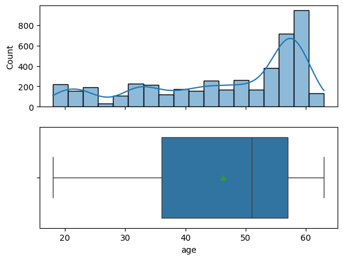

```python
def hist_box(data, feature):
  fig, ax = plt.subplots(2, 1, sharex = True)
  sns.histplot(data = data, x = feature, ax = ax[0], kde = True)
  sns.boxplot(data = data, x = feature, ax = ax[1], showmeans = True)

hist_box(data, 'age')
```

Most leads are in their late 50's, the mean being around 45

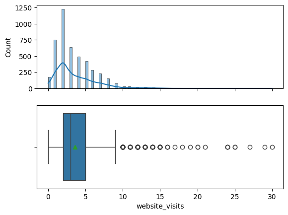

```python
hist_box(data, 'website_visits')
```

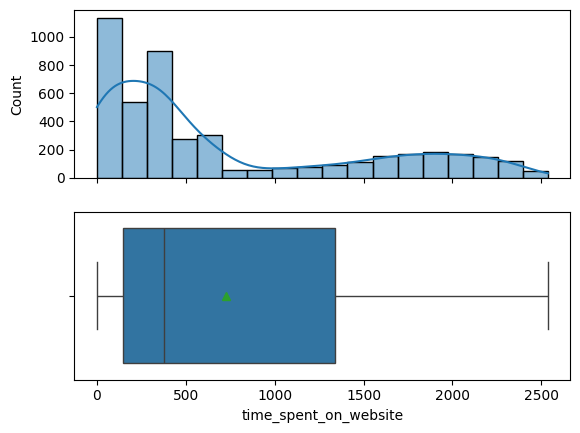

```python
hist_box(data, 'time_spent_on_website')
```

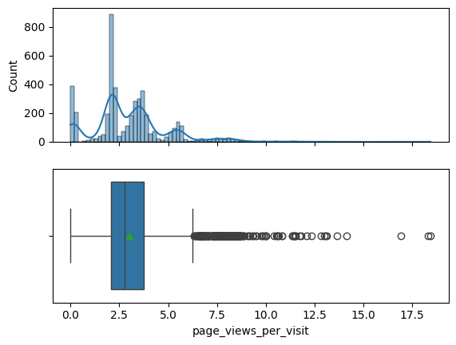

```python
hist_box(data, 'page_views_per_visit')
```

Most visitors visited 2-3 pages per visit. The mean pages per visit is around 2.5 pages.

**Bivariate Analysis**

```python
data.dtypes
```

|  | 0 |
| --- | --- |
| age | int64 |
| current_occupation | object |
| first_interaction | object |
| profile_completed | object |
| website_visits | int64 |
| time_spent_on_website | int64 |
| page_views_per_visit | float64 |
| last_activity | object |
| print_media_type1 | object |
| print_media_type2 | object |
| digital_media | object |
| educational_channels | object |
| referral | object |
| status | int64 |

**dtype:** object

```python
numeric_var = data.select_dtypes(include = ['float64', 'int64'])
numeric_var.corr()
```

|  | age | website_visits | time_spent_on_website | page_views_per_visit | status |
| --- | --- | --- | --- | --- | --- |
| age | 1.000000 | -0.011975 | 0.018885 | -0.040675 | 0.122084 |
| website_visits | -0.011975 | 1.000000 | 0.062300 | 0.074094 | -0.006609 |
| time_spent_on_website | 0.018885 | 0.062300 | 1.000000 | 0.068130 | 0.302100 |
| page_views_per_visit | -0.040675 | 0.074094 | 0.068130 | 1.000000 | 0.000307 |
| status | 0.122084 | -0.006609 | 0.302100 | 0.000307 | 1.000000 |

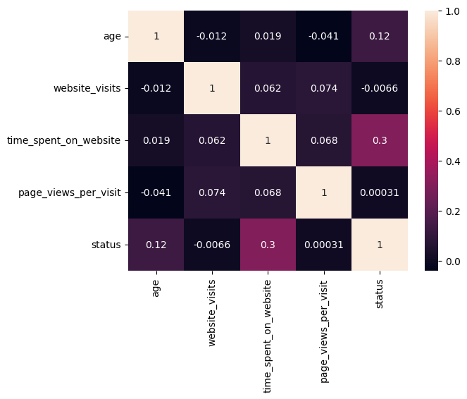

```python
sns.heatmap(data = numeric_var.corr(), annot = True)
```

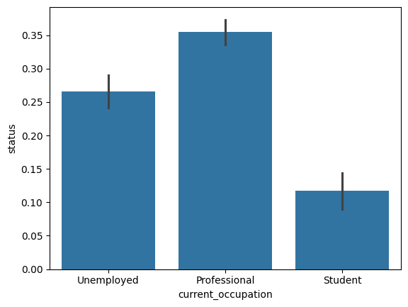

```python
sns.barplot(data = data, x = 'current_occupation', y = 'status')
```

People who's current occupation is professional will have a 35% chance of converting, and 65% chance of not.

People who's currently unemployed will have a 26% chance of converting, and 74% chance of not.

People who's a student will have a 12% chance of converting, and 88% chance of not.

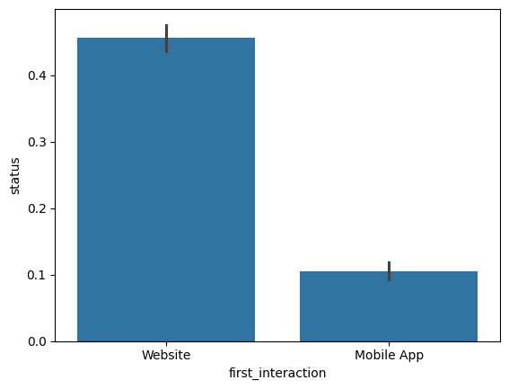

```python
sns.barplot(data = data, x = 'first_interaction', y = 'status')
```

People who's first interaction with ExtraaLearn was over a website has a 45% chance to convert to a paid customer, and 55% chance to not convert.

People who's first interaction with ExtraaLearn was on the mobile app has a 10% chance to convert to a paid customer, and 90% chance to not convert.

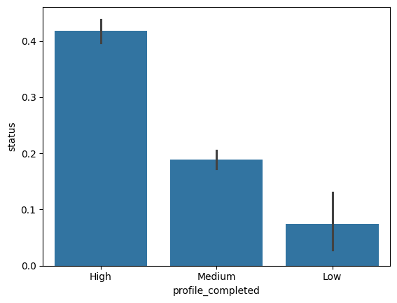

```python
sns.barplot(data = data, x = 'profile_completed', y = 'status')
```

People who complete more of their profile have a higher chance of converting to a paying customer

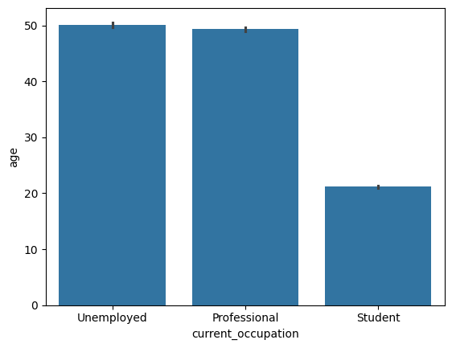

```python
sns.barplot(data = data, x = 'current_occupation', y = 'age')
```

Unemployed and employed leads were around the same average age at 50, and students were younger at around 20.

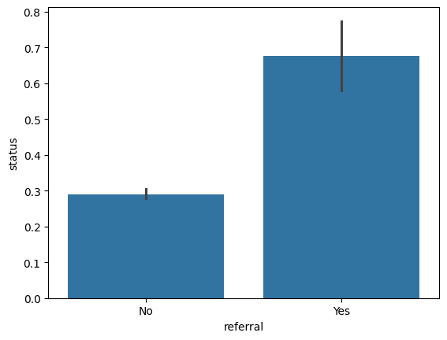

```python
sns.barplot(data = data, x = 'referral', y = 'status')
```

People who were referred to ExtraaLearn had around 65% chance of converting to a paying customer.

People who weren't referred had almost 30% chance.

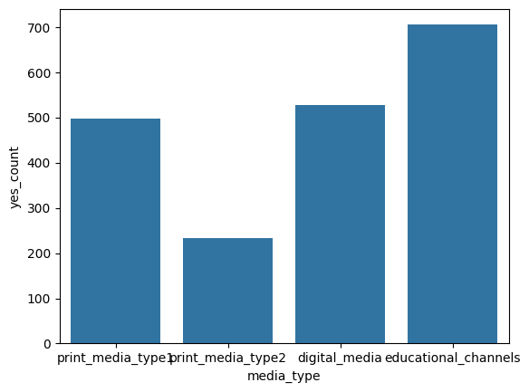

```python
media_types = ['print_media_type1', 'print_media_type2', 'digital_media', 'educational_channels']
yes_counts = pd.DataFrame(columns=['media_type', 'yes_count'])
yes_counts_list = []

for col in media_types:
    count_yes = data[data[col] == 'Yes'].shape[0]
    yes_counts_list.append({'media_type': col, 'yes_count': count_yes})

yes_counts = pd.DataFrame(yes_counts_list)

sns.barplot(data=yes_counts, x='media_type', y='yes_count')
```

This bar graph shows the number of people who said they have heard or seen ExtraaLearn for each media type. Educational channels have reached the most people.

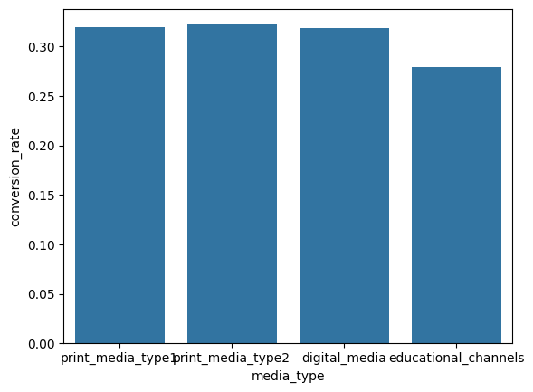

```python
media_Types = ['print_media_type1', 'print_media_type2', 'digital_media', 'educational_channels']
yes_conversion = pd.DataFrame(columns = ['media_type', 'conversion_rate'])
yes_conversion_list = []

for media in media_Types:
  yes = data[data[media] == 'Yes']
  conversion = yes[yes['status'] == 1].shape[0] / yes.shape[0]
  yes_conversion_list.append({'media_type': media, 'conversion_rate': conversion})

yes_conversion = pd.DataFrame(yes_conversion_list)
sns.barplot(data = yes_conversion, x = 'media_type', y = 'conversion_rate')
```

This bargraph shows us the people that saw each media type AND converted to a paying customer. I first created a dataframe for a single media type with customers that has seen ExtraaLearn. Then, I got the number of people that converted to a paying customer. I then divided the number of people that converted to a paying customer by the number of people that saw the media to get the conversion rate.

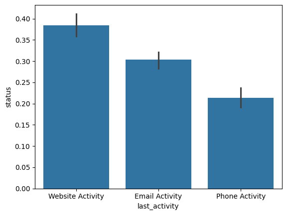

```python
sns.barplot(data = data , x = 'last_activity', y = 'status')
```

**Questions**

1. Leads will have different expectations from the outcome of the course and the current occupation may play a key role in getting them to participate in the program. Find out how current occupation affects lead status.

From my bar graph above that calculates each current occupation to status, we see that people who's current occupation is professional will have a 35% chance of converting. People who's currently unemployed will have a 26% chance of converting. People who's a student will have a 12% chance of converting.

We can conclude that people working have the highest chance of converting to a paying customer.

1. The company's first impression on the customer must have an impact. Do the first channels of interaction have an impact on the lead status?

From my bar graph that compares the status and first interactions, people who's first interaction with ExtraaLearn was over a website has a 45% chance to convert to a paid customer. People who's first interaction with ExtraaLearn was on the mobile app has a 10% chance to convert to a paid customer.

We can conclude that first channels of interaction has a significant impact on status.

1. The company uses multiple modes to interact with prospects. Which way of interaction works best?

From my bargraph that compares the modes, website mode worked best with prospects, with around 37% conversion rate.

1. The company gets leads from various channels such as print media, digital media, referrals, etc. Which of these channels have the highest lead conversion rate?

From my bargraph above that compares all media types and their conversion rates, print_media_type2, or the magazine had the highest conversion rate.

However, I also calculated how many people seen or heard of ExtraaLearn through each media type, and magazine was the lowest. People hear of ExtraaLearn far more than any other media type.

Educational channel reaches the most people. 700 leads say that they had heard about ExtraaLearn in the education channels.

We can conclude that although magazines have the highest conversion rate, they also reach the least amount of potential leads.

1. People browsing the website or mobile application are generally required to create a profile by sharing their personal data before they can access additional information.Does having more details about a prospect increase the chances of conversion?

## Data Preprocessing

- Missing value treatment (if needed)
- Feature engineering (if needed)
- Outlier detection and treatment (if needed)
- Preparing data for modeling
- Any other preprocessing steps (if needed)

```python
#Check for missing values
missing_values = data.isnull().sum()
print(missing_values)
```

```
age                      0
current_occupation       0
first_interaction        0
profile_completed        0
website_visits           0
time_spent_on_website    0
page_views_per_visit     0
last_activity            0
print_media_type1        0
print_media_type2        0
digital_media            0
educational_channels     0
referral                 0
status                   0
dtype: int64
```

There are no missing values

**Feature Engineering: One Hot Encoding** to change catergorical values into numerical format, and drops a column to prevent multicollinearity

Use one hot encoding to change categorical variables to numerical format

Drops the first category to prevent multicollinearity

```python
object_list = data.select_dtypes(include = ['object']).columns.to_list()
print(object_list)
```

```
['current_occupation', 'first_interaction', 'profile_completed', 'last_activity', 'print_media_type1', 'print_media_type2', 'digital_media', 'educational_channels', 'referral']
```

```python
data_ohe = pd.get_dummies(data = data, columns = object_list, drop_first = True)

#Convert the bools to float data type
data_ohe = data_ohe.astype(float)
data_ohe
```

|  | age | website_visits | time_spent_on_website | page_views_per_visit | status | current_occupation_Student | current_occupation_Unemployed | first_interaction_Website | profile_completed_Low | profile_completed_Medium | last_activity_Phone Activity | last_activity_Website Activity | print_media_type1_Yes | print_media_type2_Yes | digital_media_Yes | educational_channels_Yes | referral_Yes |
| --- | --- | --- | --- | --- | --- | --- | --- | --- | --- | --- | --- | --- | --- | --- | --- | --- | --- |
| 0 | 57.0 | 7.0 | 1639.0 | 1.861 | 1.0 | 0.0 | 1.0 | 1.0 | 0.0 | 0.0 | 0.0 | 1.0 | 1.0 | 0.0 | 1.0 | 0.0 | 0.0 |
| 1 | 56.0 | 2.0 | 83.0 | 0.320 | 0.0 | 0.0 | 0.0 | 0.0 | 0.0 | 1.0 | 0.0 | 1.0 | 0.0 | 0.0 | 0.0 | 1.0 | 0.0 |
| 2 | 52.0 | 3.0 | 330.0 | 0.074 | 0.0 | 0.0 | 0.0 | 1.0 | 0.0 | 1.0 | 0.0 | 1.0 | 0.0 | 0.0 | 1.0 | 0.0 | 0.0 |
| 3 | 53.0 | 4.0 | 464.0 | 2.057 | 1.0 | 0.0 | 1.0 | 1.0 | 0.0 | 0.0 | 0.0 | 1.0 | 0.0 | 0.0 | 0.0 | 0.0 | 0.0 |
| 4 | 23.0 | 4.0 | 600.0 | 16.914 | 0.0 | 1.0 | 0.0 | 1.0 | 0.0 | 0.0 | 0.0 | 0.0 | 0.0 | 0.0 | 0.0 | 0.0 | 0.0 |
| ... | ... | ... | ... | ... | ... | ... | ... | ... | ... | ... | ... | ... | ... | ... | ... | ... | ... |
| 4607 | 35.0 | 15.0 | 360.0 | 2.170 | 0.0 | 0.0 | 1.0 | 0.0 | 0.0 | 1.0 | 1.0 | 0.0 | 0.0 | 0.0 | 0.0 | 1.0 | 0.0 |
| 4608 | 55.0 | 8.0 | 2327.0 | 5.393 | 0.0 | 0.0 | 0.0 | 0.0 | 0.0 | 1.0 | 0.0 | 0.0 | 0.0 | 0.0 | 0.0 | 0.0 | 0.0 |
| 4609 | 58.0 | 2.0 | 212.0 | 2.692 | 1.0 | 0.0 | 0.0 | 1.0 | 0.0 | 0.0 | 0.0 | 0.0 | 0.0 | 0.0 | 0.0 | 0.0 | 0.0 |
| 4610 | 57.0 | 1.0 | 154.0 | 3.879 | 0.0 | 0.0 | 0.0 | 0.0 | 0.0 | 1.0 | 0.0 | 1.0 | 1.0 | 0.0 | 0.0 | 0.0 | 0.0 |
| 4611 | 55.0 | 4.0 | 2290.0 | 2.075 | 0.0 | 0.0 | 0.0 | 1.0 | 0.0 | 1.0 | 1.0 | 0.0 | 0.0 | 0.0 | 0.0 | 0.0 | 0.0 |

4612 rows × 17 columns

data_ohe is a new data table with One Hot Encoding.

**Outliers**

```python
#Use z-scores to find outliers
from scipy import stats
#Find the z-scores for all values in the column
#Find which ones are the outliers and remove

numeric_col = ['age', 'website_visits', 'time_spent_on_website', 'page_views_per_visit' ]
for column in numeric_col:
  z_scores = stats.zscore(data_ohe[column])
  outliers = ((z_scores > 3) | (z_scores < -3))
  data_ohe = data_ohe[~outliers]

print("Data shape after removing outliers:", data_ohe.shape)
```

```
Data shape after removing outliers: (4507, 17)
```

I used z-score to determine the outliers and removed them from data_ohe. We can see that around 100 rows were removed from the data set.

**Split the data into train and test**

```python
features = data_ohe.drop(columns = ['status'], axis = 1)
```

Features is a data table without the status column

```python
target = data_ohe['status']
```

target becomes the status column because it is the target variable

```python
from sklearn.model_selection import train_test_split
from sklearn.tree import DecisionTreeRegressor
from sklearn.model_selection import GridSearchCV
from sklearn.metrics import mean_absolute_error


from sklearn.metrics import mean_squared_error
from sklearn.metrics import r2_score
```

```python
features_train, features_test, target_train, target_test = train_test_split(features, target, shuffle = True, test_size = 0.2, random_state = 0)
```

```python
features_train.shape, features_test.shape
```

```
((3605, 16), (902, 16))
```

```python
def adj_r2(predictors, targets, predictions):
  r2 = r2_score(targets, predictions)
  n = predictors.shape[0]
  k = predictors.shape[1]
  return 1 - ((1 - r2) * (n - 1) / (n - k - 1))
```

n is the total number of observations

k is the total number of predictors or features

We return the adjusted R squared score because accounts for the complexity of the model by penalizing the addition of unnecessary features.

As the number of features increases, penalty increases

```python
def mape_score(targets, predictions):
  return np.mean(np.abs((targets - predictions) / targets)) * 100
```

**MAPE** measures the accuracy of your model's predictions as a percentage, indicating how far off, on average, the predictions are from the actual values.

```python
def model_performance_regression(model, predictors, targets):
  predictions = model.predict(predictors)
  r2 = r2_score(targets, predictions)
  adj_r2_value = adj_r2(predictors, targets, predictions)
  rmse = np.sqrt(mean_squared_error(targets, predictions))
  mae = mean_absolute_error(targets, predictions)

  epsilon = 1e-10  # Small value to avoid division by zero
  targets = np.where(targets == 0, epsilon, targets)  # Replace zero values with epsilon
  mape = np.mean(np.abs((targets - predictions) / targets)) * 100

  df_perf = pd.DataFrame(
        {
            'RMSE': rmse,
            'R²': [r2],
            'MAE': [mae],
            'MAPE': [mape],
            'Adjusted R²': [adj_r2_value]
        }
    )
  return df_perf
```

R² (R-Squared): Measures how well the model's predictions explain the variance in the actual target values. A value closer to 1 indicates a better fit.

Adjusted R²: Adjusts the R² score by accounting for the number of predictors in the model, providing a more accurate measure of model performance, especially when multiple features are used.

RMSE (Root Mean Squared Error): Represents the average prediction error in your model's predictions, expressed in the same units as the target variable. It indicates how far off the predictions are from the actual values on average.

MAE (Mean Absolute Error): The average absolute difference between the model's predictions and the actual target values, providing a straightforward measure of prediction accuracy.

MAPE (Mean Absolute Percentage Error): The average percentage error between the model's predictions and the actual values, indicating how far off predictions are in percentage terms.

## Building a Decision Tree model

Trains (fits) the decision tree model using the training data (features_train as the input features and target_train as the target variable). This step allows the model to learn patterns from the training data so that it can make predictions on unseen data.

```python
dt_regressor = DecisionTreeRegressor(random_state = 0)
dt_regressor.fit(features_train, target_train)
```

```
DecisionTreeRegressor(random_state=0)
```

dt_regressor: The trained Decision Tree Regressor model.

features_test: The testing dataset's features (independent variables) used for evaluation.

target_test: The actual target values (dependent variable) from the testing dataset used for comparison.

Uses dt_regressor to make predictions on features_test. It then calculates various regression metrics (R², Adjusted R², RMSE, MAE, MAPE)

```python
dt_regressor_perf_test = model_performance_regression(dt_regressor, features_test, target_test)
dt_regressor_perf_test
```

|  | RMSE | R² | MAE | MAPE | Adjusted R² |
| --- | --- | --- | --- | --- | --- |
| 0 | 0.441098 | 0.101461 | 0.195122 | 8.980044e+10 | 0.085216 |

**MAPE value is very high because of the amount of 0's in our target value (status)**

```python
features = list(features.columns)
features
```

```
['age',
 'website_visits',
 'time_spent_on_website',
 'page_views_per_visit',
 'current_occupation_Student',
 'current_occupation_Unemployed',
 'first_interaction_Website',
 'profile_completed_Low',
 'profile_completed_Medium',
 'last_activity_Phone Activity',
 'last_activity_Website Activity',
 'print_media_type1_Yes',
 'print_media_type2_Yes',
 'digital_media_Yes',
 'educational_channels_Yes',
 'referral_Yes']
```

```python
dt_regressor_visualize = DecisionTreeRegressor(random_state = 0, max_depth = 3)
dt_regressor_visualize.fit(features_train, target_train)
```

```
DecisionTreeRegressor(max_depth=3, random_state=0)
```

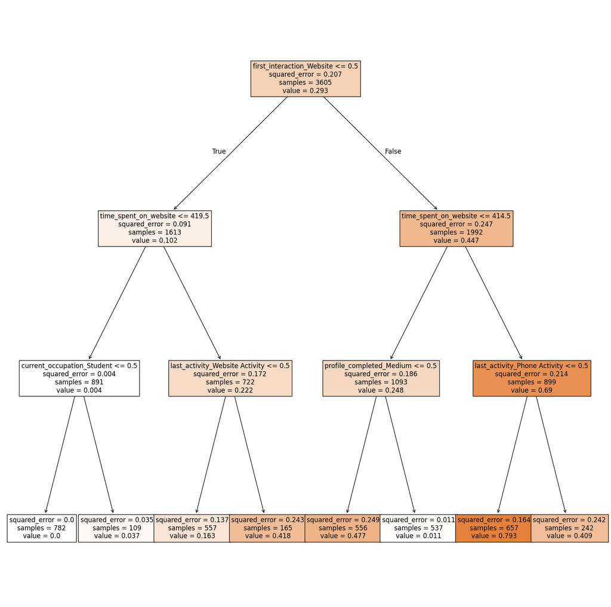

```python
from sklearn import tree
plt.figure(figsize = (20,20))
tree.plot_tree(dt_regressor_visualize, feature_names = features, filled = True, fontsize = 12, class_names = True);
```

## Do we need to prune the tree?

Bagging combines the predictions of multiple base estimators to improve the overall prediction accuracy and reduce overfitting.

```python
from sklearn.ensemble import BaggingRegressor
bagging_estimator = BaggingRegressor(random_state = 0)
bagging_estimator.fit(features_train, target_train)
```

```
BaggingRegressor(random_state=0)
```

Trains the bagging_estimator using your training data. Bagging Regressor creates multiple base estimators, each trained on a random subset of the training data.

```python
bagging_estimator_perf_test = model_performance_regression(bagging_estimator, features_test, target_test)
bagging_estimator_perf_test
```

|  | RMSE | R² | MAE | MAPE | Adjusted R² |
| --- | --- | --- | --- | --- | --- |
| 0 | 0.337867 | 0.472822 | 0.197361 | 9.312639e+10 | 0.463291 |

Run the bagging test on our model performance regression.

**Yes, we need pruning.**

The R² explains about 47% of the variance in the target variable (status) This indicates that there is still a considerable amount of unexplained variance.

**Pruning**

Create another decision tree with a max depth of 5 and mininum 10 samples before splitting.

The bagging regressor creates multiple copies (10) of the pruned tree

```python
pruned_tree = DecisionTreeRegressor(max_depth=5, min_samples_split=10, min_samples_leaf=5, random_state=0)
bagging_regressor_pruned = BaggingRegressor(estimator=pruned_tree, n_estimators=10, random_state=0)
```

```python
bagging_regressor_pruned.fit(features_train, target_train)
```

```
BaggingRegressor(estimator=DecisionTreeRegressor(max_depth=5,
                                                 min_samples_leaf=5,
                                                 min_samples_split=10,
                                                 random_state=0),
                 random_state=0)
```

```python
pruned_perf = model_performance_regression(bagging_regressor_pruned, features_test, target_test)
print(pruned_perf)
```

```
       RMSE        R²       MAE          MAPE  Adjusted R²
0  0.319049  0.529911  0.204891  9.138675e+10     0.521412
```

## Building a Random Forest model

```python
from sklearn.ensemble import RandomForestRegressor
```

RandomForestRegressor builds multiple decision trees during training and combines their predictions to improve accuracy and prevent overfitting.

```python
rf_regressor = RandomForestRegressor(random_state = 0)
rf_regressor.fit(features_train, target_train)
```

```
RandomForestRegressor(random_state=0)
```

```python
rf_regressor_perf_test = model_performance_regression(rf_regressor, features_test, target_test)
rf_regressor_perf_test
```

|  | RMSE | R² | MAE | MAPE | Adjusted R² |
| --- | --- | --- | --- | --- | --- |
| 0 | 0.331297 | 0.493124 | 0.198067 | 8.994457e+10 | 0.48396 |

## Do we need to prune the tree?

Unlike a single Decision Tree, Random Forest Regressors inherently reduce overfitting by averaging the results of multiple trees. Instead of pruning, we can tune it.

n_estimators represents the number of decision trees that will be created in the Random Forest ensemble.

You are saying that you want to try the Random Forest with 100, 110, and 120 trees, respectively.

The default value for n_estimators is 100. Including it in your parameter grid ensures that you can compare the performance of the default setting with other values.

```python
rf_tuned = RandomForestRegressor(random_state = 0)
rf_parameters = {
    'n_estimators' : [100, 110, 120],
    'max_depth' : [None, 5, 7],
    'max_features' : [0.8, 1, ]

}
rf_tuned.fit(features_train, target_train)
```

```
RandomForestRegressor(random_state=0)
```

```python
rf_grid_obj = GridSearchCV(estimator = rf_tuned, param_grid = rf_parameters, scoring = 'neg_mean_squared_error', cv = 5)
rf_grid_obj.fit(features_train, target_train)
```

```
GridSearchCV(cv=5, estimator=RandomForestRegressor(random_state=0),
             param_grid={'max_depth': [None, 5, 7], 'max_features': [0.8, 1],
                         'n_estimators': [100, 110, 120]},
             scoring='neg_mean_squared_error')
```

```python
rf_tuned_regressor = rf_grid_obj.best_estimator_
rf_tuned_regressor.fit(features_train, target_train)
```

```
RandomForestRegressor(max_depth=7, max_features=0.8, n_estimators=120,
                      random_state=0)
```

Tune the model using Grid search

```python
rf_tuned_perf_test = model_performance_regression(rf_tuned_regressor, features_test, target_test)
rf_tuned_perf_test
```

|  | RMSE | R² | MAE | MAPE | Adjusted R² |
| --- | --- | --- | --- | --- | --- |
| 0 | 0.31247 | 0.549097 | 0.194483 | 8.579519e+10 | 0.540945 |

Concatenate the test results with results from previous tests

```python
pd.concat(
    [
        rf_regressor_perf_test.T,
        pruned_perf.T,
        rf_tuned_perf_test.T,
        bagging_estimator_perf_test.T
    ],
    axis=1
).T
```

|  | RMSE | R² | MAE | MAPE | Adjusted R² |
| --- | --- | --- | --- | --- | --- |
| 0 | 0.331297 | 0.493124 | 0.198067 | 8.994457e+10 | 0.483960 |
| 0 | 0.319049 | 0.529911 | 0.204891 | 9.138675e+10 | 0.521412 |
| 0 | 0.312470 | 0.549097 | 0.194483 | 8.579519e+10 | 0.540945 |
| 0 | 0.337867 | 0.472822 | 0.197361 | 9.312639e+10 | 0.463291 |

Plot the results to see which features have the highest importance to the dataset.

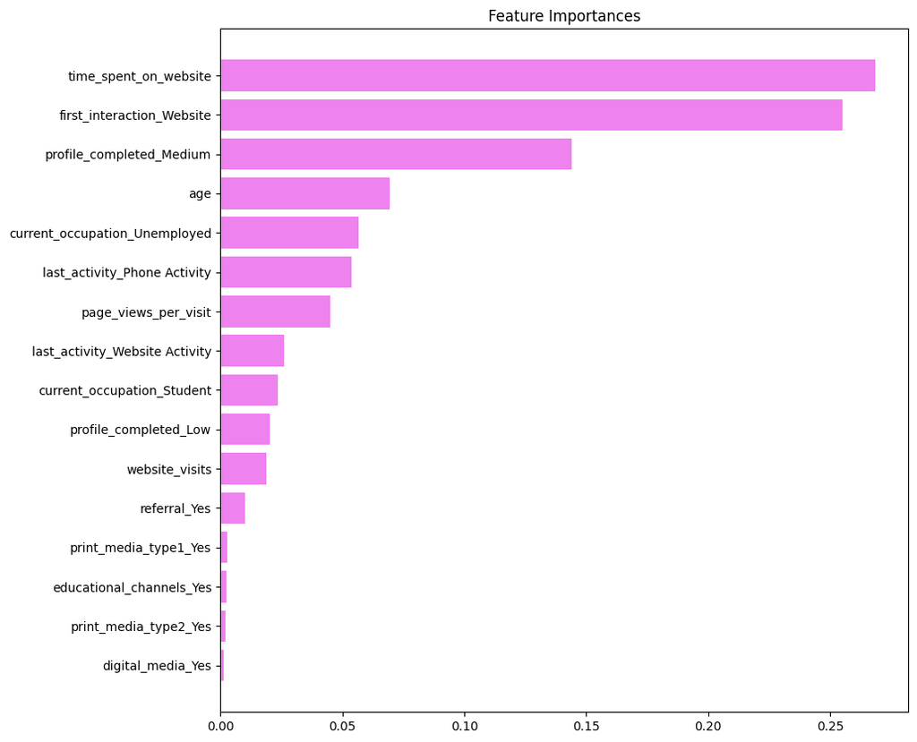

```python
import matplotlib.pyplot as plt
import numpy as np

importances = rf_tuned_regressor.feature_importances_
indices = np.argsort(importances)

plt.figure(figsize=(10, 10))
plt.title('Feature Importances')
plt.barh(range(len(features)), importances[indices], color='violet', align='center')
plt.yticks(range(len(features)), [features[i] for i in indices])
plt.show()
```

## Actionable Insights and Recommendations

**Focus on Web Experience:**

Time spent on website and First interaction on website are the most influential features. We should improve the website experience by optimizing website content, speed, and user interface to enhance user experience. This can help improve conversion rates.

**Encourage Profile Completion:**

Since profile completion levels influential features. We can encourage users to complete their profiles. We should implementing reminders to encourage users to fill in missing details, potentially increasing engagement or conversion rates.

**Personalize Targeting by Age and Occupation:**

Given that age and employment status are significant features, we should personalize marketing campaigns or website experiences based on these demographics. Tailor messages to people in the age range of 40 to 50 years old who are currently working.

**Utilize Phone and Website Activities:**

Since users' last activities on phones and websites are influential, consider integrating follow-up strategies based on these activities. For example, users who last engaged on their phone might respond well to SMS marketing, while those who engaged via the website could benefit from targeted web ads or emails.

**Optimize Onboarding for Website Interactions**

Given that first interaction on website is highly influential, ensure that the onboarding process for website visitors is seamless. This would include engaging landing pages and offering incentives for users who sign up or engage further after their first interaction.

**Target Specific Demographic Groups in Marketing Campaigns**

Utilize the information from features such as age and current occupation to create targeted marketing campaigns: For younger age groups, use social media platforms like Instagram, TikTok, or Snapchat. For students, promote student discounts or educational resources. For unemployed users, highlight job-related resources, career-building programs, or opportunities to upskill.

**Improve the Effectiveness of 'Phone Activity' and 'Website Activity' Channels**

Since last activity are important, implement follow-up strategies tailored to these channels: For users whose last activity was via phone, consider sending SMS notifications, reminders, or calls to action. For users whose last activity was through the website, leverage targeted web push notifications or personalized email campaigns.

**Analyze Content Performance on Website Pages**

Investigate why page views per visit and website visits are influencing factors. This might mean that the quality and relevance of your website content play a role in engagement. Identify high-performing pages and replicate their strategies across the website to improve overall engagement.